# Stats for DS

```python
import numpy as np
import pandas as pd
import seaborn as sns
import math
```

```python
import warnings
warnings.filterwarnings("ignore", category=DeprecationWarning)
```

## Extracting Data and Basic Ideation

The MODIS instrument is operating on both the Terra and Aqua spacecraft. It has a viewing swath width of 2,330 km and views the entire surface of the Earth every one to two days. Its detectors measure 36 spectral bands between 0.405 and 14.385 µm, and it acquires data at three spatial resolutions -- 250m, 500m, and 1,000m.

More reading on https://modis.gsfc.nasa.gov/data/

```python
modis_nrt = pd.read_csv(r"P:\UTS Academics\Sem-4\Statistical Thinking for Data Science\AT-2\Bushfire season data\fire_nrt_M6_96619.csv")
print(modis_nrt.columns)
print(modis_nrt.shape)
```

```
Index(['latitude', 'longitude', 'brightness', 'scan', 'track', 'acq_date',
       'acq_time', 'satellite', 'instrument', 'confidence', 'version',
       'bright_t31', 'frp', 'daynight'],
      dtype='object')
(183593, 14)
```

NRT stands for Near Real Time.

Further details of each column in the dataset can be found here: https://www.earthdata.nasa.gov/learn/find-data/near-real-time/firms/mcd14dl-nrt

```python
modis_nrt.info()
```

```
<class 'pandas.core.frame.DataFrame'>
RangeIndex: 183593 entries, 0 to 183592
Data columns (total 14 columns):
 #   Column      Non-Null Count   Dtype
---  ------      --------------   -----
 0   latitude    183593 non-null  float64
 1   longitude   183593 non-null  float64
 2   brightness  183593 non-null  float64
 3   scan        183593 non-null  float64
 4   track       183593 non-null  float64
 5   acq_date    183593 non-null  object
 6   acq_time    183593 non-null  int64
 7   satellite   183593 non-null  object
 8   instrument  183593 non-null  object
 9   confidence  183593 non-null  int64
 10  version     183593 non-null  object
 11  bright_t31  183593 non-null  float64
 12  frp         183593 non-null  float64
 13  daynight    183593 non-null  object
dtypes: float64(7), int64(2), object(5)
memory usage: 19.6+ MB
```

The VIIRS instrument observes and collects global satellite observations that span the visible and infrared wavelengths across land, ocean, and atmosphere. A whiskbroom radiometer by design, it has 22 channels ranging from 0.41 μm to 12.01 μm. Five of these channels are high-resolution image bands or I-bands, and sixteen serve as moderate-resolution bands or M-bands. VIIRS also hosts a unique panchromatic Day/Night band (DNB), which is ultra-sensitive in low-light conditions that allows us to observe nighttime lights with better spatial and temporal resolutions compared to previously provided nighttime lights data by the Defense Meteorological Satellite Program.

More reading on https://ladsweb.modaps.eosdis.nasa.gov/missions-and-measurements/viirs/

```python
viirs_nrt = pd.read_csv(r"P:\UTS Academics\Sem-4\Statistical Thinking for Data Science\AT-2\Bushfire season data\fire_nrt_V1_96617.csv")
print(viirs_nrt.columns)
print(viirs_nrt.shape)
```

```
Index(['latitude', 'longitude', 'bright_ti4', 'scan', 'track', 'acq_date',
       'acq_time', 'satellite', 'instrument', 'confidence', 'version',
       'bright_ti5', 'frp', 'daynight'],
      dtype='object')
(956257, 14)
```

Further details of each column in the dataset can be found here: https://www.earthdata.nasa.gov/learn/find-data/near-real-time/firms/vnp14imgtdlnrt

```python
viirs_nrt.info()
```

```
<class 'pandas.core.frame.DataFrame'>
RangeIndex: 956257 entries, 0 to 956256
Data columns (total 14 columns):
 #   Column      Non-Null Count   Dtype
---  ------      --------------   -----
 0   latitude    956257 non-null  float64
 1   longitude   956257 non-null  float64
 2   bright_ti4  956257 non-null  float64
 3   scan        956257 non-null  float64
 4   track       956257 non-null  float64
 5   acq_date    956257 non-null  object
 6   acq_time    956257 non-null  int64
 7   satellite   956257 non-null  object
 8   instrument  956257 non-null  object
 9   confidence  956257 non-null  object
 10  version     956257 non-null  object
 11  bright_ti5  956257 non-null  float64
 12  frp         956257 non-null  float64
 13  daynight    956257 non-null  object
dtypes: float64(7), int64(1), object(6)
memory usage: 102.1+ MB
```

To better understand the Australian bushfire 2019-20.

**The NRT datasets capture data from 1 Oct, 2019 to 11 Jan, 2020 which is the period of the bushfire.**

**The archive datasets capture data from 1 Aug, 2019 to 30 Sept, 2019 which is right before the bushfire.**

```python
modis_archive = pd.read_csv(r"P:\UTS Academics\Sem-4\Statistical Thinking for Data Science\AT-2\Bushfire season data\fire_archive_M6_96619.csv")
print(modis_archive.columns)
print(modis_archive.shape)
```

```
Index(['latitude', 'longitude', 'brightness', 'scan', 'track', 'acq_date',
       'acq_time', 'satellite', 'instrument', 'confidence', 'version',
       'bright_t31', 'frp', 'daynight', 'type'],
      dtype='object')
(36011, 15)
```

```python
viirs_archive = pd.read_csv(r"P:\UTS Academics\Sem-4\Statistical Thinking for Data Science\AT-2\Bushfire season data\fire_archive_V1_96617.csv")
print(viirs_archive.columns)
print(viirs_archive.shape)
```

```
Index(['latitude', 'longitude', 'bright_ti4', 'scan', 'track', 'acq_date',
       'acq_time', 'satellite', 'instrument', 'confidence', 'version',
       'bright_ti5', 'frp', 'type'],
      dtype='object')
(184778, 14)
```

```python
%matplotlib inline
import matplotlib.pyplot as plt
import matplotlib.lines as mlines
# For 3D projection plotting
from mpl_toolkits.mplot3d import Axes3D
from sklearn.model_selection import train_test_split, learning_curve
from sklearn.metrics import average_precision_score
from sklearn.metrics import mean_squared_error
```

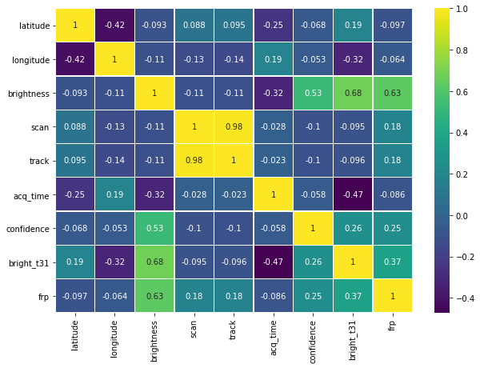

```python
plt.figure(figsize=(10,7))
sns.heatmap(modis_nrt.corr(),cmap='viridis', linewidths=0.30, annot=True);
```

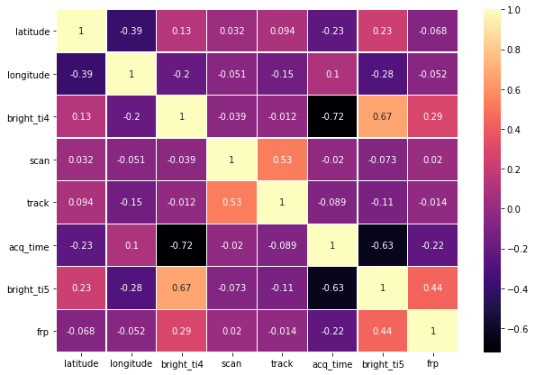

```python
plt.figure(figsize=(10,7))
sns.heatmap(viirs_nrt.corr(),cmap='magma', linewidths=0.30, annot=True);
```

```python
frames = [viirs_archive, viirs_nrt]

viirs = pd.concat(frames)
viirs.shape
```

```
(1141035, 15)
```

```python
x = viirs.drop(columns=['frp', 'latitude', 'longitude', 'acq_date', 'acq_time', 'satellite', 'instrument', 'daynight', 'version', 'confidence','type'])
y = viirs['frp']
```

```python
x.isnull().sum()
```

```
bright_ti4    0
scan          0
track         0
bright_ti5    0
dtype: int64
```

```python
from sklearn.model_selection import train_test_split

x_train, x_test, y_train, y_test = train_test_split(x, y, test_size=0.2, random_state=2)
```

```python
from sklearn import metrics
from sklearn.model_selection import cross_val_score

results_df = pd.DataFrame()
columns = ["Model", "Cross Val Score", "MAE", "MSE", "RMSE", "R2"]

def evaluate(true, predicted):
    mae = metrics.mean_absolute_error(true, predicted)
    mse = metrics.mean_squared_error(true, predicted)
    rmse = np.sqrt(metrics.mean_squared_error(true, predicted))
    r2_square = metrics.r2_score(true, predicted)
    return mae, mse, rmse, r2_square

def append_results(model_name, model, results_df, y_test, pred):
    results_append_df = pd.DataFrame(data=[[model_name, *evaluate(y_test, pred) , cross_val_score(model, x, y, cv=10).mean()]], columns=columns)
    results_df = results_df.append(results_append_df, ignore_index = True)
    return results_df
```

Robust Regression best deals with outliers

```python
from sklearn.linear_model import RANSACRegressor
ransacReg = RANSACRegressor()
ransacReg.fit(x_train, y_train)
pred= ransacReg.predict(x_test)

results_df = append_results("Robust Regression", RANSACRegressor(), results_df, y_test,pred)
results_df
```

|  | Model | Cross Val Score | MAE | MSE | RMSE | R2 |
| --- | --- | --- | --- | --- | --- | --- |
| 0 | Robust Regression | 10.297906 | 1763.437421 | 41.993302 | -0.005542 | 0.001131 |

Lower the RMSE - Better the performance, Lower MSE the better